# Santa Barbara Breeding Bird Study

Linus Blomqvist

3/2/2021

Here, I explore ways to present data from the Santa Barbara Breeding Bird Study. Since this is exploratory, it should not be cited.

# Data prep

There are 36 types of breeding evidence in the dataset. We are focusing on 15 of them in the following categories:

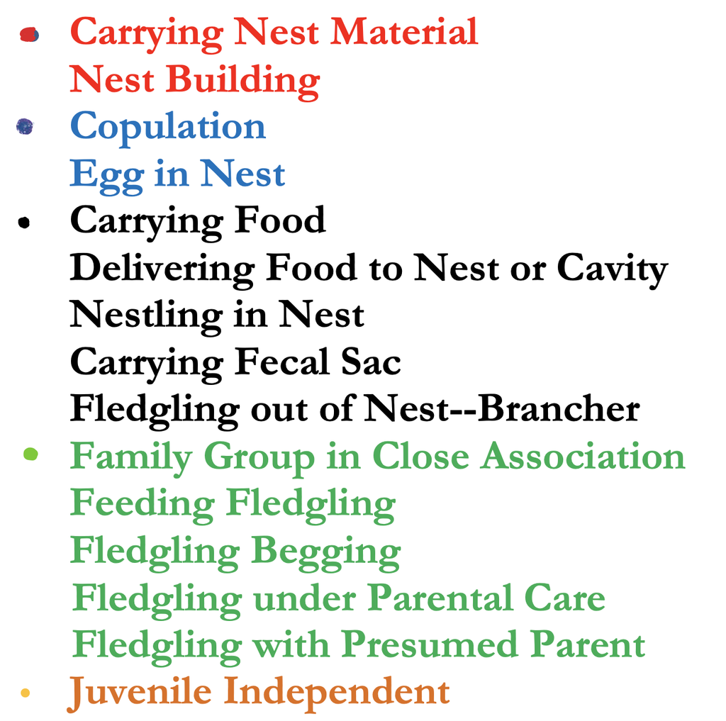

These categories are described as follows:

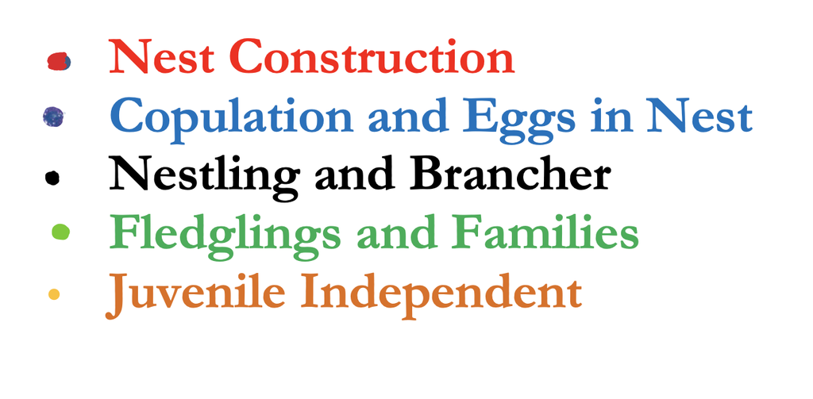

I also standardize the date format and make a new variable for week.

# Scatterplots (with lines)

## Red-tailed Hawk

This is a manual template for a figure:

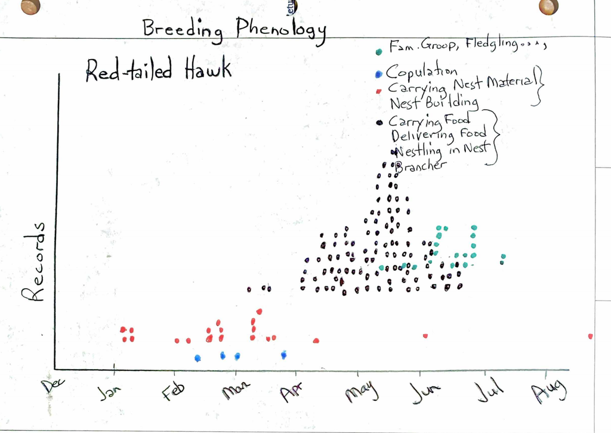

Red-tailed Hawk graph

Here I filter observations only for Red-tailed Hawk, then summarize across week and group of evidence (among 5 groups).

And then plot it. Each dot is the number of observations in a given week for a given type of evidence, across all years. The color denotes the evidence category.

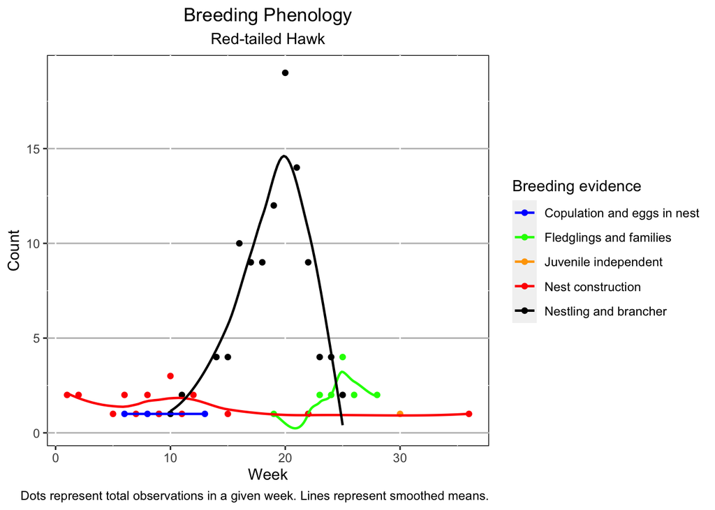

## White-tailed Kite

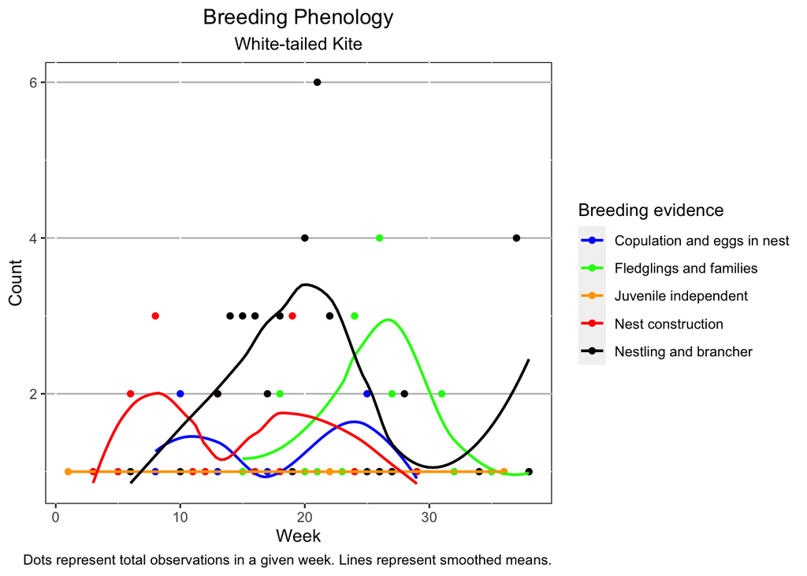

## Cooper’s Hawk

[figure not shown]

## Red-shouldered Hawk

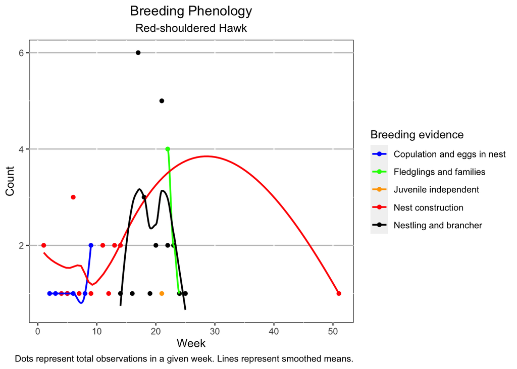

# Boxplots

## Red-tailed Hawk

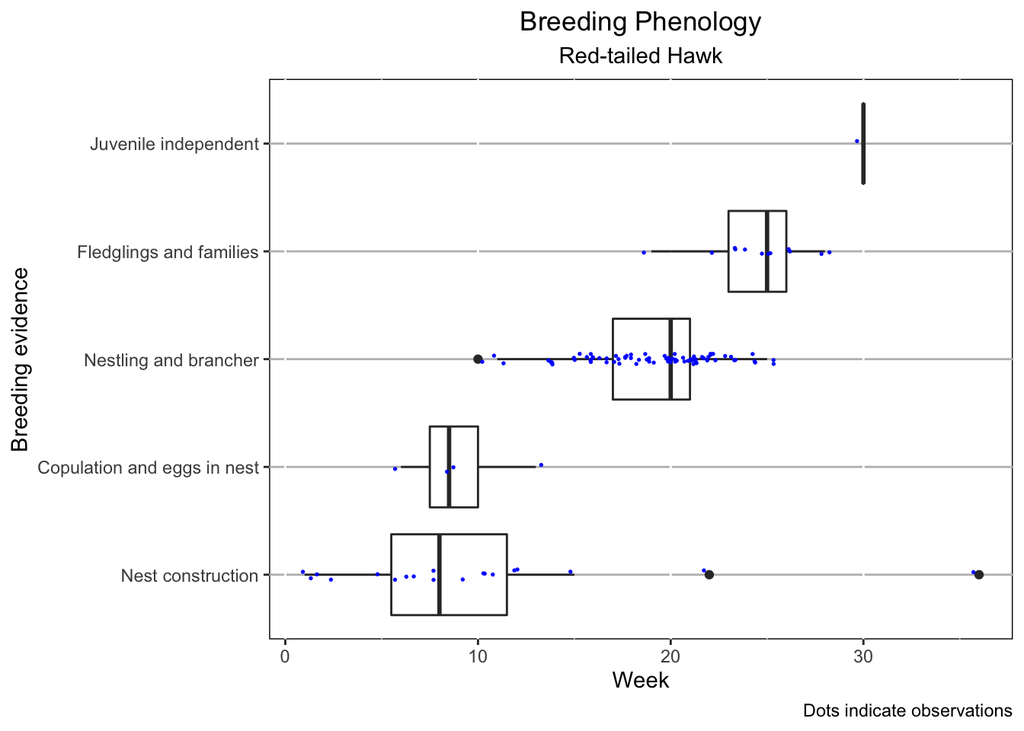

# Multi-density chart

## Red-tailed Hawk

Ignore colors and other layout here

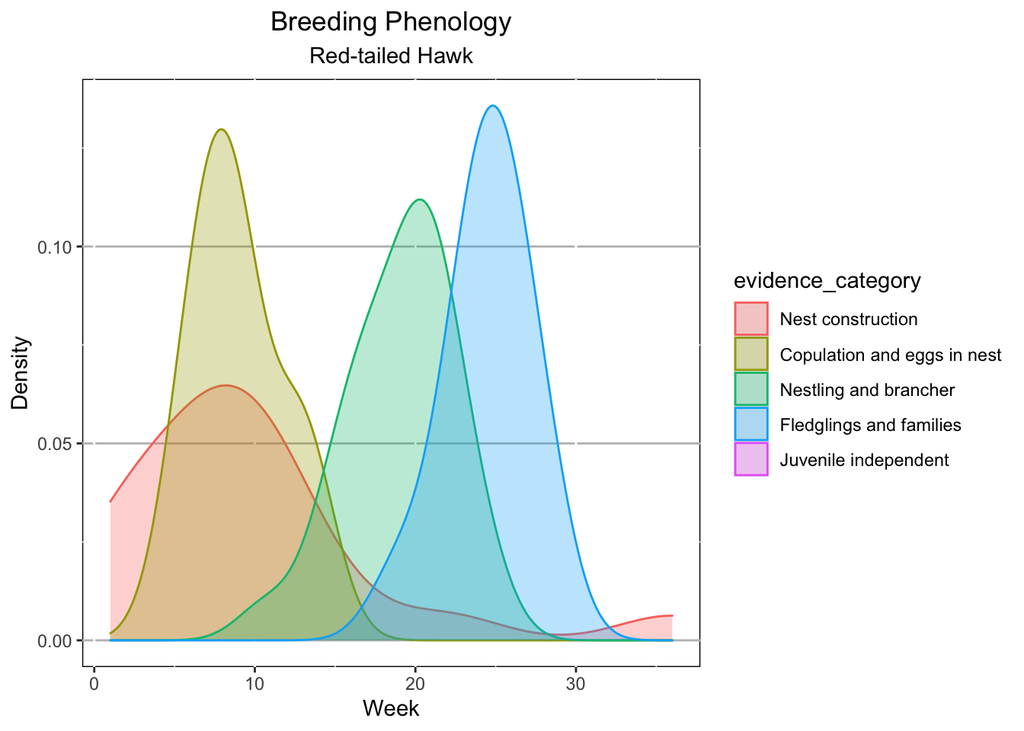

## European Starling

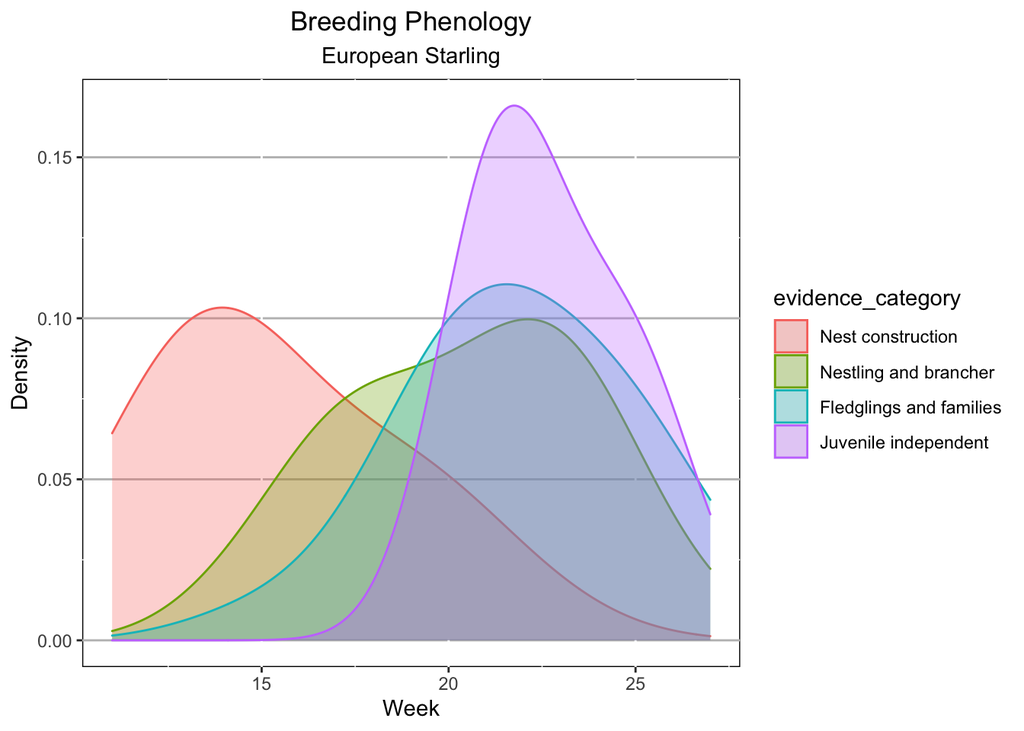

## Mallard

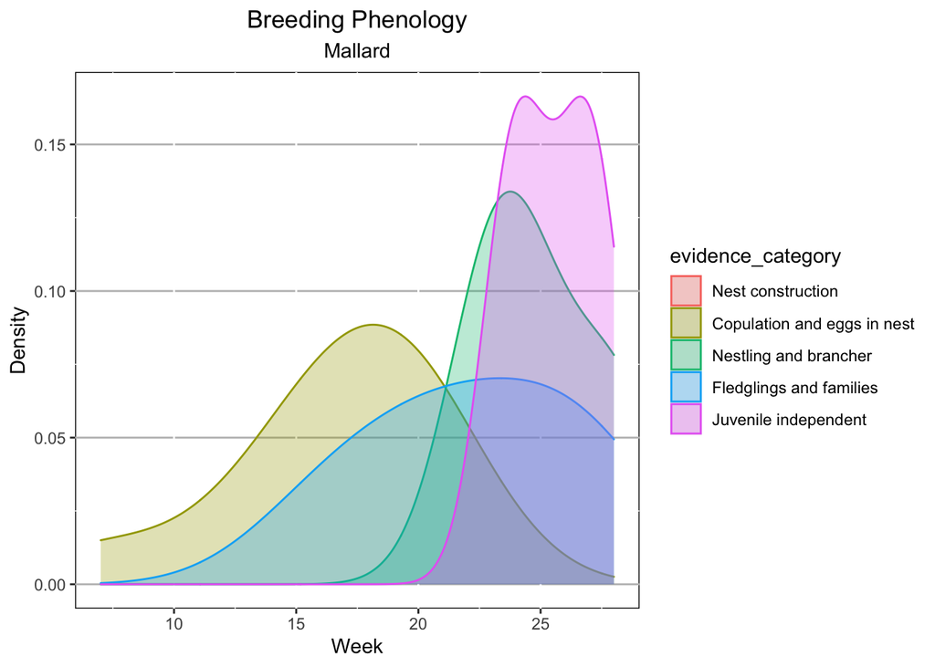

## Gadwall

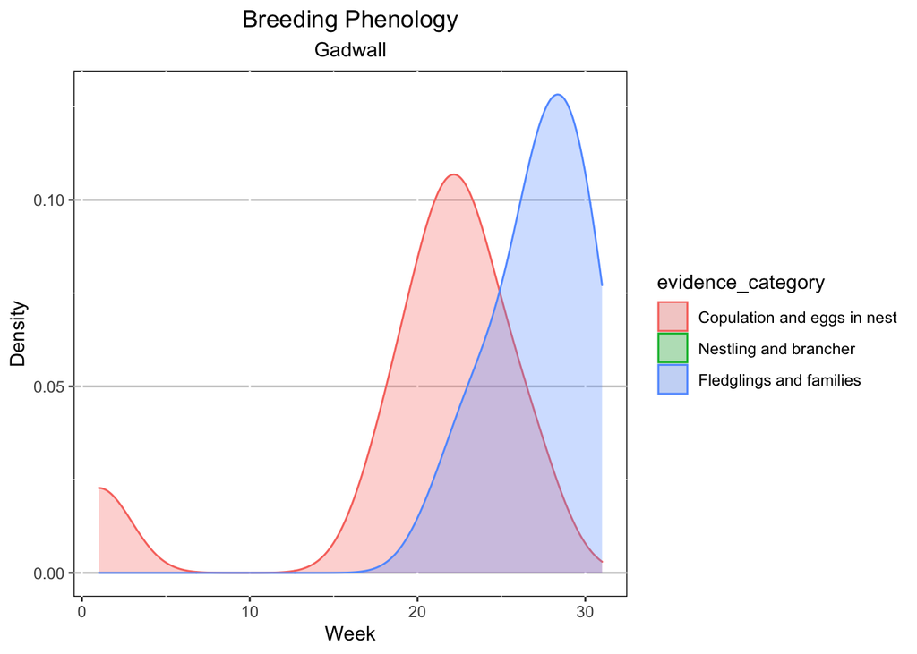